# Analysis on Accelometers using Machine Learning

Ravi Teja L

25/11/2020

# Executive Summary

### Background

Using devices such as Jawbone Up, Nike FuelBand, and Fitbit it is now possible to collect a large amount of data about personal activity relatively inexpensively. These type of devices are part of the quantified self movement - a group of enthusiasts who take measurements about themselves regularly to improve their health, to find patterns in their behavior, or because they are tech geeks. One thing that people regularly do is quantify how much of a particular activity they do, but they rarely quantify how well they do it. The goal of this project is to use data from accelerometers on the belt, forearm, arm, and dumbbell of 6 participants as they perform barbell lifts correctly and incorrectly 5 different ways.

Six young healthy participants were asked to perform one set of 10 repetitions of the Unilateral Dumbbell Biceps Curl in five different fashions: * Class A - exactly according to the specification * Class B - throwing the elbows to the front * Class C - liting the dumbbell only halfway * Class D - lowering the dumbbell only halfway * Class E - throwing the hips to the front

Class A corresponds to the specified execution of the exercise, while the other 4 classes correspond to common mistakes. Participants were supervised by an experienced weight lifter to make sure the execution complied to the manner they were supposed to simulate. The exercises were performed by six male participants aged between 20-28 years, with little weight lifting experience. Researchers made sure that all participants could easily simulate the mistakes in a safe and controlled manner by using a relatively light dumbbell (1.25kg).

### Reference

Velloso, E.; Bulling, A.; Gellersen, H.; Ugulino, W.; Fuks, H. Qualitative Activity Recognition of Weight Lifting Exercises. Proceedings of 4th International Conference in Cooperation with SIGCHI (Augmented Human ’13). Stuttgart, Germany: ACM SIGCHI, 2013.

### Data

The training data for this project are available at:

https://d396qusza40orc.cloudfront.net/predmachlearn/pml-training.csv

The test data are available at:

https://d396qusza40orc.cloudfront.net/predmachlearn/pml-testing.csv

### Goal

The goal of this project is to predict the manner in which subjects did the exercise. This is the “classe” variable in the training set. The model will use the other variables to predict with. This report describes: * how the model is built * use of cross validation * an estimate of expected out of sample error

## **Loading the Libraries and Packages**

```r
library(caret)
```

```r
library(RColorBrewer)
library(rpart)
library(rpart.plot)
library(rattle)
set.seed(1)
```

## **Loading the links**

```r
train.url <- "https://d396qusza40orc.cloudfront.net/predmachlearn/pml-training.csv"
test.url <-  "https://d396qusza40orc.cloudfront.net/predmachlearn/pml-testing.csv"

path <- paste(getwd(), sep="")

train.file <- file.path(path, "pml-training.csv")
test.file  <- file.path(path, "pml-testing.csv")
```

## **Download if file doesnot exist**

```r
if(!file.exists(train.file)) { download.file(train.url, dest.file=train.file) }
if(!file.exists(test.file)) { download.file(test.url, destfile = test.file) }
```

## **Loading the Data**

```r
train.data.raw <- read.csv(train.file, na.strings = c("NA", "#DIV/0", ""))
test.data.raw <- read.csv(test.file, na.strings = c("NA", "#DIV/0", ""))
```

## **Summarizing the Data**

### Dimensions of DataSet

```r
dim(train.data.raw)
```

```
## [1] 19622   160
```

```r
dim(test.data.raw)
```

```
## [1]  20 160
```

### Types of Attributes

```r
sapply(train.data.raw, class)
```

```
##                        X                user_name     raw_timestamp_part_1
##                "integer"              "character"                "integer"
##     raw_timestamp_part_2           cvtd_timestamp               new_window
##                "integer"              "character"              "character"
##               num_window                roll_belt               pitch_belt
##                "integer"                "numeric"                "numeric"
##                 yaw_belt         total_accel_belt       kurtosis_roll_belt
##                "numeric"                "integer"              "character"
##      kurtosis_picth_belt        kurtosis_yaw_belt       skewness_roll_belt
##              "character"              "character"              "character"
##     skewness_roll_belt.1        skewness_yaw_belt            max_roll_belt
##              "character"              "character"                "numeric"
##           max_picth_belt             max_yaw_belt            min_roll_belt
##                "integer"              "character"                "numeric"
##           min_pitch_belt             min_yaw_belt      amplitude_roll_belt
##                "integer"              "character"                "numeric"
##     amplitude_pitch_belt       amplitude_yaw_belt     var_total_accel_belt
##                "integer"              "character"                "numeric"
##            avg_roll_belt         stddev_roll_belt            var_roll_belt
##                "numeric"                "numeric"                "numeric"
##           avg_pitch_belt        stddev_pitch_belt           var_pitch_belt
##                "numeric"                "numeric"                "numeric"
##             avg_yaw_belt          stddev_yaw_belt             var_yaw_belt
##                "numeric"                "numeric"                "numeric"
##             gyros_belt_x             gyros_belt_y             gyros_belt_z
##                "numeric"                "numeric"                "numeric"
##             accel_belt_x             accel_belt_y             accel_belt_z
##                "integer"                "integer"                "integer"
##            magnet_belt_x            magnet_belt_y            magnet_belt_z
##                "integer"                "integer"                "integer"
##                 roll_arm                pitch_arm                  yaw_arm
##                "numeric"                "numeric"                "numeric"
##          total_accel_arm            var_accel_arm             avg_roll_arm
##                "integer"                "numeric"                "numeric"
##          stddev_roll_arm             var_roll_arm            avg_pitch_arm
##                "numeric"                "numeric"                "numeric"
##         stddev_pitch_arm            var_pitch_arm              avg_yaw_arm
##                "numeric"                "numeric"                "numeric"
##           stddev_yaw_arm              var_yaw_arm              gyros_arm_x
##                "numeric"                "numeric"                "numeric"
```

[output cut: 53 more lines]

```
##              "character"                "integer"                "numeric"
##         avg_roll_forearm      stddev_roll_forearm         var_roll_forearm
##                "numeric"                "numeric"                "numeric"
##        avg_pitch_forearm     stddev_pitch_forearm        var_pitch_forearm
##                "numeric"                "numeric"                "numeric"
##          avg_yaw_forearm       stddev_yaw_forearm          var_yaw_forearm
##                "numeric"                "numeric"                "numeric"
##          gyros_forearm_x          gyros_forearm_y          gyros_forearm_z
##                "numeric"                "numeric"                "numeric"
##          accel_forearm_x          accel_forearm_y          accel_forearm_z
##                "integer"                "integer"                "integer"
##         magnet_forearm_x         magnet_forearm_y         magnet_forearm_z
##                "integer"                "numeric"                "numeric"
##                   classe
##              "character"
```

### Cleaning the DataSet

```r
# Drop first 7 columns as they're unnecessary for predicting

train.data.clean1 <- train.data.raw[, 8:length(colnames(train.data.raw))]
test.data.clean1 <- test.data.raw[, 8:length(colnames(test.data.raw))]

# Drop columns with NA's

train.data.clean1 <- train.data.clean1[, colSums(is.na(train.data.clean1)) == 0]
test.data.clean1 <- test.data.clean1[, colSums(is.na(test.data.clean1)) == 0]
test.data.clean1 <- test.data.clean1[, 1:length(names(test.data.clean1))-1]
```

### Sample look at the Data

```r
head(train.data.clean1)
```

```
##   roll_belt pitch_belt yaw_belt total_accel_belt gyros_belt_x gyros_belt_y
## 1      1.41       8.07    -94.4                3         0.00         0.00
## 2      1.41       8.07    -94.4                3         0.02         0.00
## 3      1.42       8.07    -94.4                3         0.00         0.00
## 4      1.48       8.05    -94.4                3         0.02         0.00
## 5      1.48       8.07    -94.4                3         0.02         0.02
## 6      1.45       8.06    -94.4                3         0.02         0.00
##   gyros_belt_z accel_belt_x accel_belt_y accel_belt_z magnet_belt_x
## 1        -0.02          -21            4           22            -3
## 2        -0.02          -22            4           22            -7
## 3        -0.02          -20            5           23            -2
## 4        -0.03          -22            3           21            -6
## 5        -0.02          -21            2           24            -6
## 6        -0.02          -21            4           21             0
##   magnet_belt_y magnet_belt_z roll_arm pitch_arm yaw_arm total_accel_arm
```

[output cut: 62 more lines]

### Levels of Class

```r
levels(factor(train.data.clean1$classe))
```

```
## [1] "A" "B" "C" "D" "E"
```

### Class Distribution

```r
percentage <- prop.table(table(train.data.clean1$classe))*100
cbind(freq = table(train.data.clean1$classe), percentage = percentage)
```

```
##   freq percentage
## A 5580   28.43747
## B 3797   19.35073
## C 3422   17.43961
## D 3216   16.38977
## E 3607   18.38243
```

## **Validating the Training Data**

```r
validation_index <- createDataPartition(train.data.clean1$classe, p = 0.70, list = FALSE)
train.data.final <- train.data.clean1[validation_index,]
validate.data.final <- train.data.clean1[-validation_index,]
test.data.final <- test.data.clean1
```

## **Statistical Summary**

```r
summary(train.data.final)
```

```
##    roll_belt        pitch_belt          yaw_belt       total_accel_belt
##  Min.   :-28.90   Min.   :-54.7000   Min.   :-180.00   Min.   : 0.00
##  1st Qu.:  1.09   1st Qu.:  1.7900   1st Qu.: -88.30   1st Qu.: 3.00
##  Median :113.00   Median :  5.3000   Median : -13.60   Median :17.00
##  Mean   : 64.22   Mean   :  0.3364   Mean   : -11.65   Mean   :11.28
##  3rd Qu.:123.00   3rd Qu.: 14.9000   3rd Qu.:  10.80   3rd Qu.:18.00
##  Max.   :162.00   Max.   : 60.3000   Max.   : 179.00   Max.   :29.00
##   gyros_belt_x        gyros_belt_y       gyros_belt_z      accel_belt_x
##  Min.   :-1.040000   Min.   :-0.64000   Min.   :-1.3500   Min.   :-120.000
##  1st Qu.:-0.030000   1st Qu.: 0.00000   1st Qu.:-0.2000   1st Qu.: -21.000
##  Median : 0.030000   Median : 0.02000   Median :-0.1000   Median : -15.000
##  Mean   :-0.004551   Mean   : 0.03973   Mean   :-0.1311   Mean   :  -5.638
##  3rd Qu.: 0.110000   3rd Qu.: 0.11000   3rd Qu.:-0.0200   3rd Qu.:  -5.000
##  Max.   : 2.200000   Max.   : 0.64000   Max.   : 1.6200   Max.   :  81.000
##   accel_belt_y     accel_belt_z     magnet_belt_x    magnet_belt_y
##  Min.   :-38.00   Min.   :-275.00   Min.   :-48.00   Min.   :359.0
##  1st Qu.:  3.00   1st Qu.:-162.00   1st Qu.:  9.00   1st Qu.:581.0
##  Median : 34.00   Median :-151.00   Median : 35.00   Median :601.0
##  Mean   : 30.08   Mean   : -72.32   Mean   : 55.39   Mean   :593.9
##  3rd Qu.: 61.00   3rd Qu.:  28.00   3rd Qu.: 59.00   3rd Qu.:610.0
##  Max.   :164.00   Max.   : 104.00   Max.   :479.00   Max.   :673.0
##  magnet_belt_z       roll_arm         pitch_arm          yaw_arm
##  Min.   :-623.0   Min.   :-180.00   Min.   :-88.800   Min.   :-180.0000
##  1st Qu.:-375.0   1st Qu.: -31.20   1st Qu.:-25.700   1st Qu.: -42.7000
##  Median :-320.0   Median :   0.00   Median :  0.000   Median :   0.0000
##  Mean   :-345.4   Mean   :  17.88   Mean   : -4.546   Mean   :  -0.4896
##  3rd Qu.:-306.0   3rd Qu.:  77.00   3rd Qu.: 11.200   3rd Qu.:  45.9000
##  Max.   : 293.0   Max.   : 180.00   Max.   : 88.200   Max.   : 180.0000
##  total_accel_arm  gyros_arm_x        gyros_arm_y       gyros_arm_z
##  Min.   : 1.00   Min.   :-6.37000   Min.   :-3.4400   Min.   :-2.330
##  1st Qu.:17.00   1st Qu.:-1.33000   1st Qu.:-0.8000   1st Qu.:-0.070
##  Median :27.00   Median : 0.08000   Median :-0.2400   Median : 0.230
##  Mean   :25.54   Mean   : 0.04636   Mean   :-0.2589   Mean   : 0.267
##  3rd Qu.:33.00   3rd Qu.: 1.57000   3rd Qu.: 0.1400   3rd Qu.: 0.720
##  Max.   :66.00   Max.   : 4.87000   Max.   : 2.8400   Max.   : 3.020
##   accel_arm_x       accel_arm_y      accel_arm_z       magnet_arm_x
##  Min.   :-404.00   Min.   :-318.0   Min.   :-636.00   Min.   :-584.0
##  1st Qu.:-243.00   1st Qu.: -53.0   1st Qu.:-143.00   1st Qu.:-303.0
##  Median : -47.00   Median :  14.0   Median : -47.00   Median : 282.0
##  Mean   : -61.55   Mean   :  33.2   Mean   : -71.04   Mean   : 189.6
```

[output cut: 43 more lines]

```
##  Max.   :311.00000   Max.   :231.0000   Max.   : 477.00   Max.   : 923.0
##  accel_forearm_z   magnet_forearm_x  magnet_forearm_y magnet_forearm_z
##  Min.   :-446.00   Min.   :-1280.0   Min.   :-896.0   Min.   :-966.0
##  1st Qu.:-182.00   1st Qu.: -615.0   1st Qu.:  -3.0   1st Qu.: 189.0
##  Median : -39.00   Median : -378.0   Median : 587.0   Median : 510.0
##  Mean   : -55.14   Mean   : -312.1   Mean   : 377.9   Mean   : 393.3
##  3rd Qu.:  26.00   3rd Qu.:  -76.0   3rd Qu.: 736.0   3rd Qu.: 652.0
##  Max.   : 291.00   Max.   :  672.0   Max.   :1480.0   Max.   :1090.0
##     classe
##  Length:13737
##  Class :character
##  Mode  :character
##
##
##
```

## **Visualization**

### Univariate plots

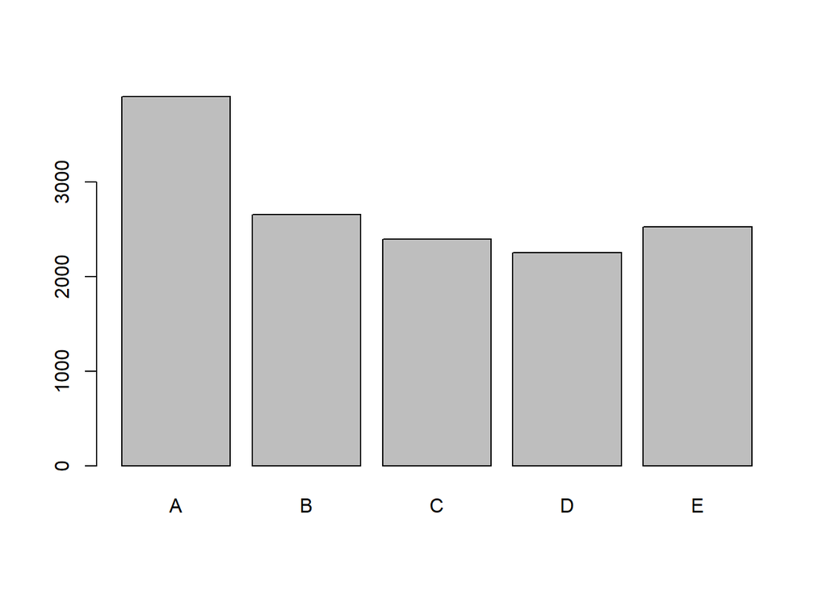

```r
l <- 1:length(names(train.data.final))
x <- train.data.final[,l-1]
y <- train.data.final$classe
plot(factor(y))
```

The DataSet has higher number of columns making it hard for univariate or multivariate analysis

## **Testing Different Algorithms**

### 5-fold Cross Validation

```r
control <- trainControl(method = "cv", number = 5)
metric <- "Accuracy"
```

### Building Models

```r
set.seed(7)
lda.model <- train(classe~., data = train.data.final, method="lda", metric=metric, trControl=control)
set.seed(7)
rf.model <- train(classe~., data = train.data.final, method="rf", metric=metric, trControl=control)
```

## **Selecting the Best Model**

```r
results <- resamples(list(lda = lda.model, rf = rf.model))
summary(results)
```

```
##
## Call:
## summary.resamples(object = results)
##
## Models: lda, rf
## Number of resamples: 5
##
## Accuracy
##          Min.   1st Qu.    Median      Mean   3rd Qu.      Max. NA's
## lda 0.6883873 0.7007645 0.7037846 0.7016809 0.7069530 0.7085153    0
## rf  0.9894430 0.9894469 0.9901711 0.9903909 0.9912664 0.9916272    0
##
## Kappa
##          Min.   1st Qu.    Median      Mean   3rd Qu.      Max. NA's
## lda 0.6052826 0.6204166 0.6257122 0.6224708 0.6299013 0.6310413    0
## rf  0.9866417 0.9866521 0.9875647 0.9878440 0.9889505 0.9894110    0
```

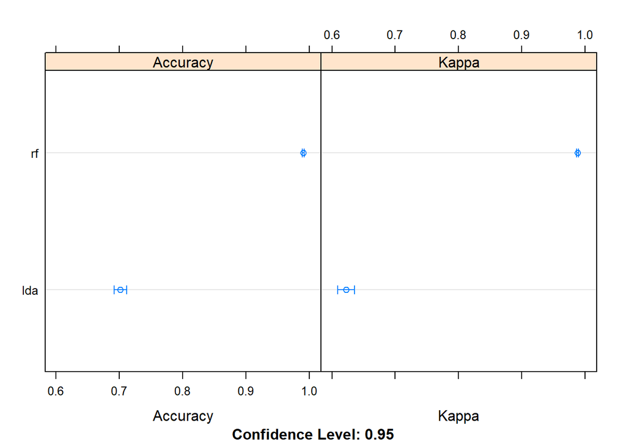

```r
dotplot(results)
```

The results for Random Forests can be summarized as it provides high accuracy.

The training data set is used to fit a Random Forest model because it automatically selects important variables and is robust to correlated covariates & outliers in general.A Random forest is a way of reducing the variance.This typically produces better performance at the expense of bias and interpret-ability.

```r
print(rf.model)
```

```
## Random Forest
##
## 13737 samples
##    52 predictor
##     5 classes: 'A', 'B', 'C', 'D', 'E'
##
## No pre-processing
## Resampling: Cross-Validated (5 fold)
## Summary of sample sizes: 10990, 10990, 10989, 10989, 10990
## Resampling results across tuning parameters:
##
##   mtry  Accuracy   Kappa
##    2    0.9900999  0.9874762
##   27    0.9903909  0.9878440
##   52    0.9826016  0.9779889
##
## Accuracy was used to select the optimal model using the largest value.
## The final value used for the model was mtry = 27.
```

## **Decision Tree Visualization**

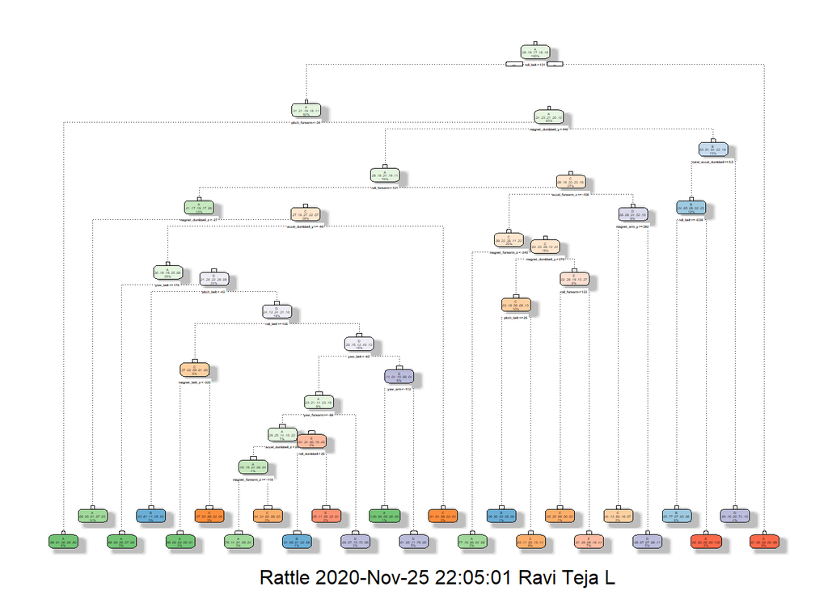

```r
astree <- rpart(classe~.,data=train.data.final,method = "class")
fancyRpartPlot(astree)
```

## **Validation**

### Validating the Training Data

```r
predictions <- predict(rf.model, validate.data.final)
confusionmatrix <- confusionMatrix(predictions, as.factor(validate.data.final$classe))
acc.out <-  confusionmatrix$overall["Accuracy"]
ose <- 1-as.numeric(confusionmatrix$overall[1])
confusionmatrix
```

```
## Confusion Matrix and Statistics
##
##           Reference
## Prediction    A    B    C    D    E
##          A 1670    6    0    0    2
##          B    3 1132   11    0    0
##          C    1    0 1007   16    0
##          D    0    1    8  947    3
##          E    0    0    0    1 1077
##
## Overall Statistics
##
##                Accuracy : 0.9912
##                  95% CI : (0.9884, 0.9934)
##     No Information Rate : 0.2845
##     P-Value [Acc > NIR] : < 2.2e-16
##
##                   Kappa : 0.9888
##
##  Mcnemar's Test P-Value : NA
##
## Statistics by Class:
##
##                      Class: A Class: B Class: C Class: D Class: E
## Sensitivity            0.9976   0.9939   0.9815   0.9824   0.9954
## Specificity            0.9981   0.9971   0.9965   0.9976   0.9998
## Pos Pred Value         0.9952   0.9878   0.9834   0.9875   0.9991
## Neg Pred Value         0.9990   0.9985   0.9961   0.9965   0.9990
## Prevalence             0.2845   0.1935   0.1743   0.1638   0.1839
## Detection Rate         0.2838   0.1924   0.1711   0.1609   0.1830
## Detection Prevalence   0.2851   0.1947   0.1740   0.1630   0.1832
## Balanced Accuracy      0.9979   0.9955   0.9890   0.9900   0.9976
```

The Model Fit is using the tested data is used against validation data.validated Data for the data are then compared to the original values.This allows forcasting the accuracy and overall out-of-sample error, which indicate how well the model will perform with other data. Provided the **0.991164** accuracy and overall out of sample error being **0.008836** we can safely assume we achieve desired results and that our model is can be dependable for prediction

### Testing

```r
predictions <- predict(rf.model, test.data.final)
predictions
```

```
##  [1] B A B A A E D B A A B C B A E E A B B B
## Levels: A B C D E
```